# R Notebook

First steps : Data Viz From : http://r4ds.had.co.nz/data-visualisation.html#prerequisites-1

```r
library(ggplot2)
mpg
```

| manufacturer | model | displ | year | cyl | trans | drv | cty | hwy | fl | class |
| --- | --- | --- | --- | --- | --- | --- | --- | --- | --- | --- |
| audi | a4 | 1.8 | 1999 | 4 | auto(l5) | f | 18 | 29 | p | compact |
| audi | a4 | 1.8 | 1999 | 4 | manual(m5) | f | 21 | 29 | p | compact |
| audi | a4 | 2.0 | 2008 | 4 | manual(m6) | f | 20 | 31 | p | compact |
| audi | a4 | 2.0 | 2008 | 4 | auto(av) | f | 21 | 30 | p | compact |
| audi | a4 | 2.8 | 1999 | 6 | auto(l5) | f | 16 | 26 | p | compact |
| audi | a4 | 2.8 | 1999 | 6 | manual(m5) | f | 18 | 26 | p | compact |
| audi | a4 | 3.1 | 2008 | 6 | auto(av) | f | 18 | 27 | p | compact |
| audi | a4 quattro | 1.8 | 1999 | 4 | manual(m5) | 4 | 18 | 26 | p | compact |
| audi | a4 quattro | 1.8 | 1999 | 4 | auto(l5) | 4 | 16 | 25 | p | compact |
| audi | a4 quattro | 2.0 | 2008 | 4 | manual(m6) | 4 | 20 | 28 | p | compact |

[output cut: 224 more lines]

The mpg data frame has variables displ (car’s engine size in ltrs) and hwy (fuel efficiency on highway)

Creating a ggplot

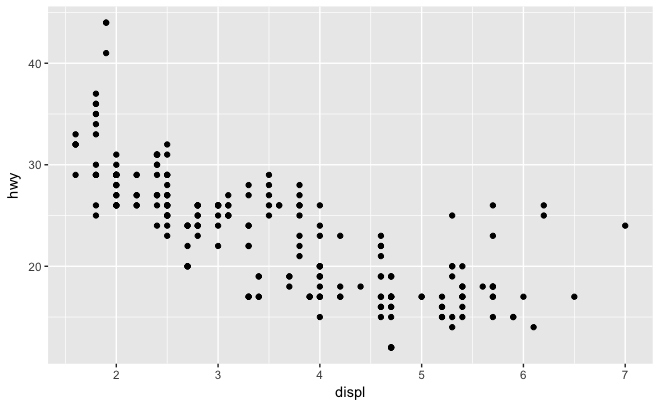

```r
ggplot(data = mpg) +
  geom_point(mapping = aes(x = displ, y = hwy))
```

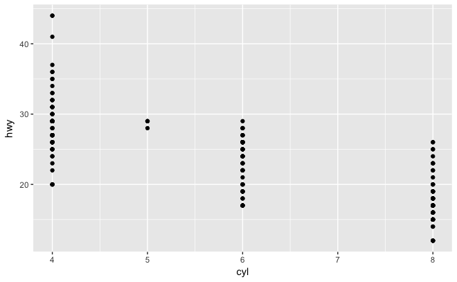

```r
ggplot(data = mpg) +
  geom_point(mapping = aes(x = cyl, y = hwy))
```

Adding + creates a layer on the plot. geom_mapping (point, line) etc maps data variables to the plot

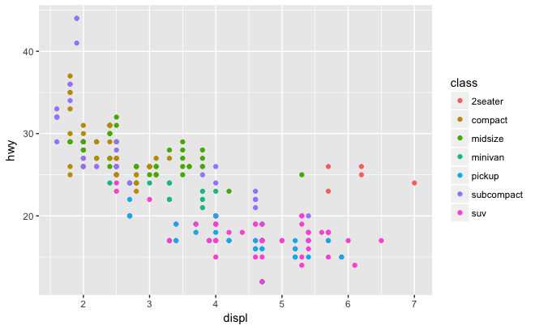

```r
ggplot(data = mpg) +
  geom_point(mapping = aes(x = displ, y = hwy, color = class ))
```

To map an aesthetic to a variable, associate the name of the aesthetic to the name of the variable inside aes(). Mapping an uordered variable like class to color is a good idea. However mapping an unordered variable to size is a bad idea.

```r
class(mpg$class)
```

```
[1] "character"
```

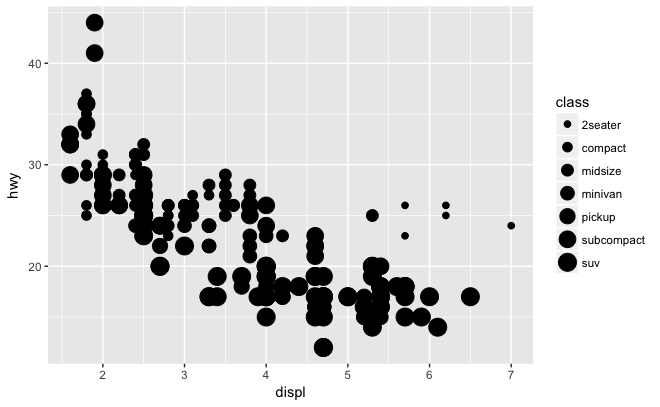

```r
ggplot(data = mpg) +
  geom_point(mapping = aes(x = displ, y = hwy, size = class ))
```

Other options for unordered variables are alpha and shape

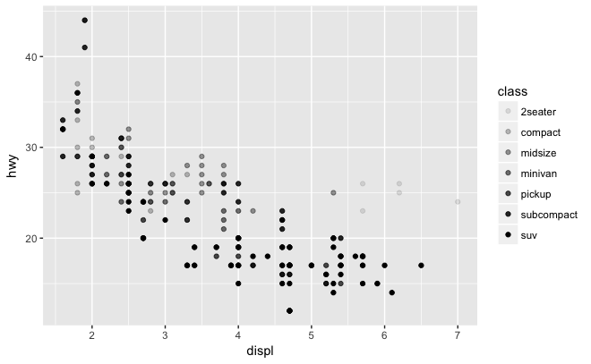

```r
ggplot(data = mpg) +
  geom_point(mapping = aes(x = displ, y = hwy, alpha = class))
```

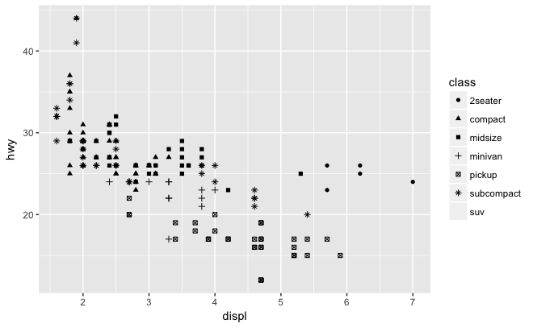

```r
ggplot(data = mpg) +
  geom_point(mapping = aes(x = displ, y = hwy, shape = class))
```

Map same variable to multiple aesthetics

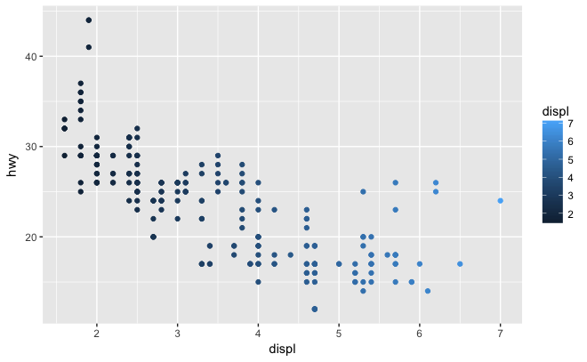

```r
ggplot(data = mpg) +
  geom_point(mapping = aes(x = displ, y = hwy, color = displ))
```

```r
?geom_point
```

Facets : split variables according to categories (levels) of a categorical variable

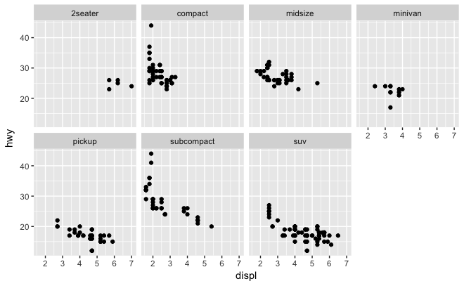

```r
ggplot(data = mpg) +
  geom_point(mapping = aes(x = displ, y = hwy)) +
  facet_wrap(~ class, nrow = 2)
```

To facet your plot on the combination of two variables, add facet_grid() to your plot call. The first argument of facet_grid() is also a formula. This time the formula should contain two variable names separated by a ~.

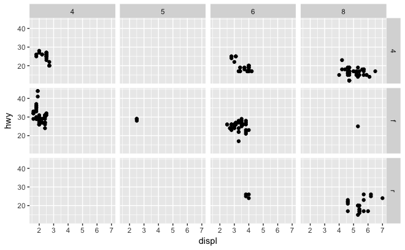

```r
ggplot(data = mpg) +
  geom_point(mapping = aes(x = displ, y = hwy)) +
  facet_grid(drv ~ cyl)
```

Facet with a continuous variable

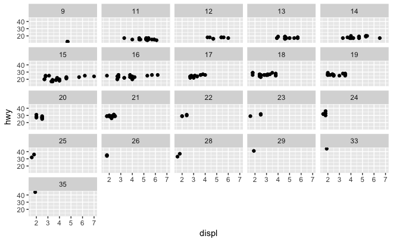

```r
ggplot(data = mpg) +
  geom_point(mapping = aes(x = displ, y = hwy)) +
  facet_wrap(~ cty)
```

```r
summary(mpg)
```

```
 manufacturer          model               displ
 Length:234         Length:234         Min.   :1.600
 Class :character   Class :character   1st Qu.:2.400
 Mode  :character   Mode  :character   Median :3.300
                                       Mean   :3.472
                                       3rd Qu.:4.600
                                       Max.   :7.000
      year           cyl           trans
 Min.   :1999   Min.   :4.000   Length:234
 1st Qu.:1999   1st Qu.:4.000   Class :character
 Median :2004   Median :6.000   Mode  :character
 Mean   :2004   Mean   :5.889
 3rd Qu.:2008   3rd Qu.:8.000
 Max.   :2008   Max.   :8.000
     drv                 cty             hwy
 Length:234         Min.   : 9.00   Min.   :12.00
 Class :character   1st Qu.:14.00   1st Qu.:18.00
 Mode  :character   Median :17.00   Median :24.00
                    Mean   :16.86   Mean   :23.44
                    3rd Qu.:19.00   3rd Qu.:27.00
                    Max.   :35.00   Max.   :44.00
      fl               class
 Length:234         Length:234
 Class :character   Class :character
 Mode  :character   Mode  :character
```

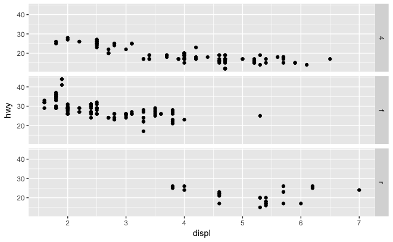

```r
ggplot(data = mpg) +
  geom_point(mapping = aes(x = displ, y = hwy)) +
  facet_grid(drv ~ .)
```

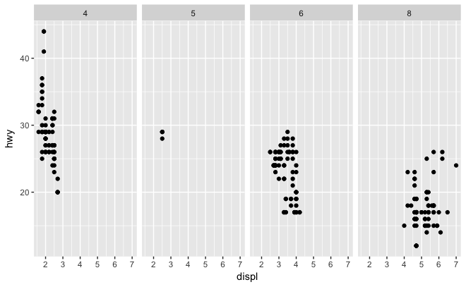

```r
ggplot(data = mpg) +
  geom_point(mapping = aes(x = displ, y = hwy)) +
  facet_grid(. ~ cyl)
```

Smooth mapping using geom_smooth

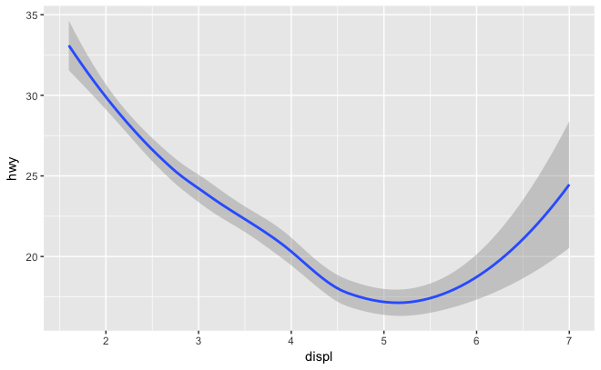

```r
ggplot(data = mpg) +
  geom_smooth(mapping = aes(x = displ, y = hwy))
```

Similar to geom object color in geom_point, we can use linetype in geom_smooth

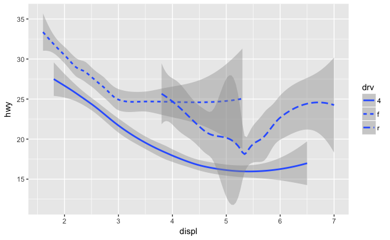

```r
ggplot(data = mpg) +
  geom_smooth(mapping = aes(x = displ, y = hwy, linetype = drv))
```

Adding multiple geoms : global an local mapping Global mapping to the gggplot function. Any local mapping comes in the geom function

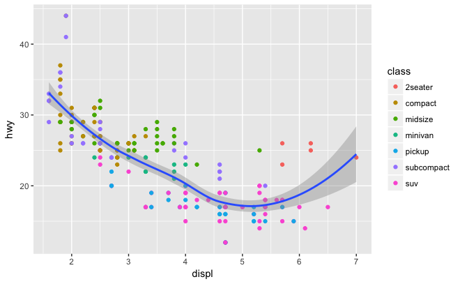

```r
ggplot(data = mpg, mapping = aes(x = displ, y = hwy)) +
  geom_point(mapping = aes(color = class)) +
  geom_smooth()
```

Some geoms transform the data and produce a statistical transformation. For example geom_bar plots the count of a categorical data. The y variable is the “transformed” variable.

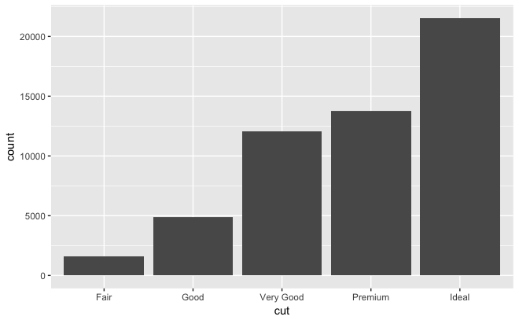

```r
ggplot(data = diamonds) +
  geom_bar(mapping = aes(x = cut))
```

```r
?geom_bar
```